# Integration des données hydrobiologiques

```r
knitr::opts_chunk$set(echo = TRUE)

# Packages utilisés
library(config) # Utilisation d'un fichier de configuration, cf  https://db.rstudio.com/best-practices/managing-credentials/#stored-in-a-file-with-config
library(tidyverse)
library(DBI) # pour les connexions aux BDD
library(RPostgreSQL) # driver postgres
library(RMariaDB) # driver MariaDB
library(RMySQL) # driver MySQL
library(lubridate) # calcul sur les dates
library(httr) #
library(jsonlite) # Gestion format json
library("readxl") # Lecture de fichiers xlsx

library(sf) # Traitement de données géoréférencées
```

```r
library(mapview) # Affichage de données géoréférencées
library(plotly) # Graphiques interactifs
library(leaflet) # Cartes interactives

# Fonction pour requêter l'API Hub'Eau

get_hubeau <- function(path, query) {

  response <- GET(url = path, query = query) %>%
  content(as = "text", encoding = "UTF-8") %>%
  fromJSON(flatten = TRUE)

data = response$data # Le jeu de données est dans l'objet "data"

if(response$count > query$size) { # Si la taille de page est plus petite que le nb de résultats, faire une boucle pour les pages suivantes

pages <- ceiling(response$count/query$size)

# Affichage d'une barre de progression
pb <- winProgressBar(title = "Récupération des chroniques", min = 0,
                     max = pages, width = 300)

for(i in 2:pages){

  query$page <- i

  response_i <- GET(url = path, query = query) %>%
  content(as = "text", encoding = "UTF-8") %>%
  fromJSON(flatten = TRUE)

data <- rbind(data, response_i$data) # Concaténation des lignes récupérées

setWinProgressBar(pb, i, title=paste( round(i/pages*100, 0), "% chargé")) # Avancement de la barre de progression

} # Fin boucle for

close(pb)

} # Fin if

return(data)
  } # Fin get_hubeau

# Insertion de données

db.insertion <- function(con,table,data) {

  # Date de la dernière donnée en base
  Date_max <- tbl(con, table) %>% summarise(Date_max = max(Date_de_la_mesure, na.rm = TRUE)) %>% pull(Date_max)
  if(is.na(Date_max)) Date_max <- as.Date(params$date_debut)-1

  # Données plus récentes à insérer
  data <- data %>% filter(Date_de_la_mesure > Date_max)

  # Existe-t-il des données à insérer ?
if (isTRUE(data %>% tally() > 0)) {

  # Insertion des nouvelles lignes
  dbWriteTable(con, table, data, overwrite=FALSE, append=TRUE,
             fileEncoding="latin1")

  # Horodate en commentaire
mise_a_jour <- paste0(format.Date(Sys.Date(),"%d/%m/%Y"), " : Actualisation ",params$actualisation)

dbGetQuery(con, paste0("ALTER TABLE ",table," COMMENT = '",mise_a_jour,"';"))

paste0("Données insérées : ",data%>%tally)

}
  else {

    paste0("Aucune donnée à insérer depuis le ", format.Date(Date_max,"%d/%m/%Y"))

    }

} # fin db.insertion
```

# Connexion aux bases de données pour l’intégration des données importées

```r
# Base Mariadb OEB - eau_tbi
con_eau_tbi <- dbConnect(RMariaDB::MariaDB(), default.file = '../../.my.cnf', groups="mysql_oeb",
dbname = "eau_tbi")

# Base MariaDB OEB - référentiels
con_referentiels <- dbConnect(RMariaDB::MariaDB(), default.file = '../../.my.cnf', groups="mysql_oeb",
dbname = "eau_referentiels")

# Base Postgres (développement)

conf <- config::get("postgres_dev")

con_postgresql_dev <- DBI::dbConnect(odbc::odbc(),
                          Driver       = conf$driver,
                          servername   = conf$server,
                          UID = conf$uid,
                          PWD = conf$pwd,
                          Port = conf$port,
                          database = 'eau',
                             encoding = "latin1")
```

# Collecte des données de la base Naïades à partir de l’API Hydrobiologie du portail Hub’eau

**Documentation de l’API :** https://hubeau.eaufrance.fr/page/api-hydrobiologie

```r
# Récupération des infos sur les stations de mesure

# Liste des paramètres de la requête
query_sites = list(
  code_departement= params$num_departement,
  format='json',
  size=params$pagination
  )

# Requête des stations
hubeau_sites <- get_hubeau(path = params$api_sites, query = query_sites)

# Conversion au format géographique
sites <- st_as_sf(hubeau_sites, coords = c("coordonnee_x", "coordonnee_y"),
    crs = 2154, agr = "constant")

# Récupération des résultats d'indices biologiques

# Liste des paramètres de la requête (lot 1 de départements)
query_resultats = list(
                 #code_departement = params$num_departement,
                 code_departement = "29,22,35",
                 code_indice = params$codes_parametres,
                 #les paramètres date_debut et date_fin créent un bug dans l'API https://github.com/BRGM/hubeau/issues/81
                 #date_debut_prelevement = params$date_debut,
                 #date_fin_prelevement = params$date_fin,
                 size = params$pagination,
                 format = 'json')

# Requête des chroniques
hubeau_resultats <- get_hubeau(path = params$api_resultats, query=query_resultats)

# Liste des paramètres de la requête (lot 2 de départements)
query_resultats = list(
                 #code_departement = params$num_departement,
                 code_departement = "56,50,44,49,53",
                 code_indice = params$codes_parametres,
                 #les paramètres date_debut et date_fin créent un bug dans l'API https://github.com/BRGM/hubeau/issues/81
                 #date_debut_prelevement = params$date_debut,
                 #date_fin_prelevement = params$date_fin,
                 size = params$pagination,
                 format = 'json')

# Requête des chroniques
hubeau_resultats <- get_hubeau(path = params$api_resultats, query=query_resultats)%>%union(hubeau_resultats)

# Conversion au format géographique
resultats <- st_as_sf(hubeau_resultats, coords = c("coordonnee_x", "coordonnee_y"),
    crs = 2154, agr = "constant")
```

- path : adresse de l’API
- query : liste des paramètres de requête avec leurs valeurs (code_)

Les départements séparés en deux lots pour respecter les contraintes de nb de lignes totales récupérées par requête.

# Import des référentiels géographiques

Les polygones des territoires de SAGE bretons sont récupérées depuis le flux WFS de la DREAL Bretagne, ils correspondent au périmètre géographique des données à bancariser.

```r
# couche des SAGEs bretons depuis Geobretagne
sages <- st_read("https://geobretagne.fr/geoserver/dreal_b/sage_dreal/wfs?SERVICE=WFS&REQUEST=GetCapabilities")
# pb pas moyen de manipuler cet objet => solution sur
# https://gis.stackexchange.com/questions/389814/r-st-centroid-geos-error-unknown-wkb-type-12/389854#389854
ensure_multipolygons <- function(X) {
  tmp1 <- tempfile(fileext = ".gpkg")
  tmp2 <- tempfile(fileext = ".gpkg")
  st_write(X, tmp1)
  gdalUtilities::ogr2ogr(tmp1, tmp2, f = "GPKG", nlt = "MULTIPOLYGON")
  Y <- st_read(tmp2)
  st_sf(st_drop_geometry(X), geom = st_geometry(Y))
}

sages <- ensure_multipolygons(sages)
```

```
## Writing layer `file3f6c5b5d7a6b' to data source
##   `C:\Users\tbesse\AppData\Local\Temp\RtmpsB4Eyh\file3f6c5b5d7a6b.gpkg' using driver `GPKG'
## Writing 21 features with 7 fields and geometry type Multi Surface.
```

```r
# couche des Hydroécorégions de niveau 2

her2 <- st_read("https://services.sandre.eaufrance.fr/geo/mdo?SERVICE=WFS&VERSION=2.0.0&REQUEST=GetFeature&typename=Hydroecoregion2")%>%
  st_transform(2154)
```

# Sélection des sites et des résultats sur les territoires des SAGE bretons

Les sites et résultats téléchargés sont sélectionnés sur le périmètre géographique retenu, par jointure avec la couche des SAGE.

```r
sites_sages <- sites %>%
  st_join(sages) %>%
  filter(!is.na(cd_sage))

resultats_sages <- resultats %>%
  st_join(sages) %>%
  filter(!is.na(cd_sage)) %>%
  st_join(her2)
```

## Les sites font-ils partie du réseau RCS ?

L’information sur le réseau de suivi est incluse dans les données sur les sites fournies par l’API. Le réseau RCS correspond au code SANDRE : 0000000052

```r
sites_rcs <- sites_sages %>%
  # rowwise pour préciser que les opérations se font pour chaque ligne
  rowwise()%>%
  # Le code 0000000052 (RCS) est dans la liste des codes_réseaux
  mutate(inclus_rcs = '0000000052' %in% unlist(codes_reseaux))%>%
  select(code_station_hydrobio, inclus_rcs)
```

## Carte des sites importés via Hub’eau, par département

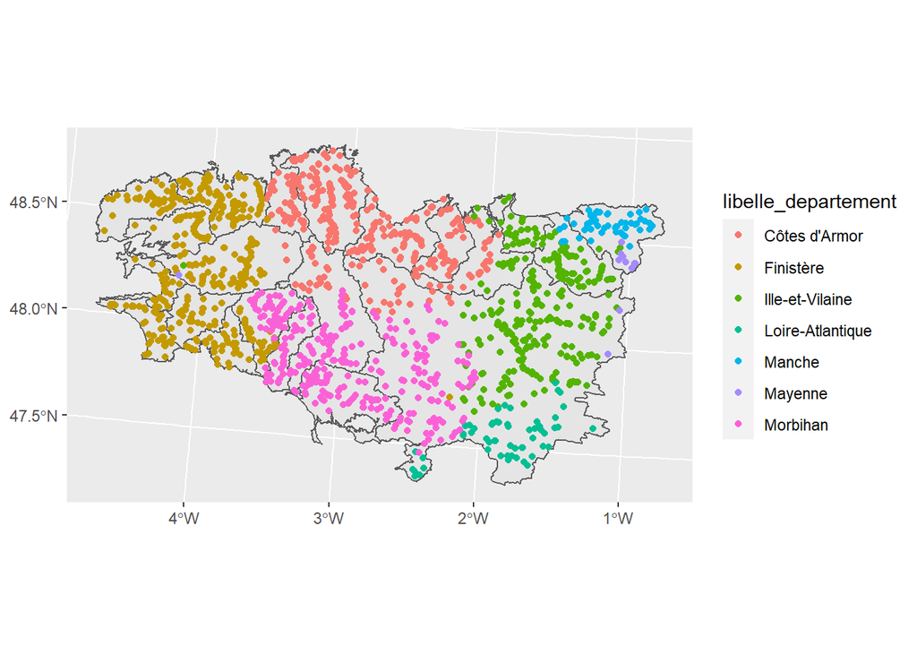

```r
sites_sages %>%
  ggplot()+
  geom_sf(data=sages)+
geom_sf(aes(color=libelle_departement))
```

## Carte des résultats importés via Hub’eau, par qualification

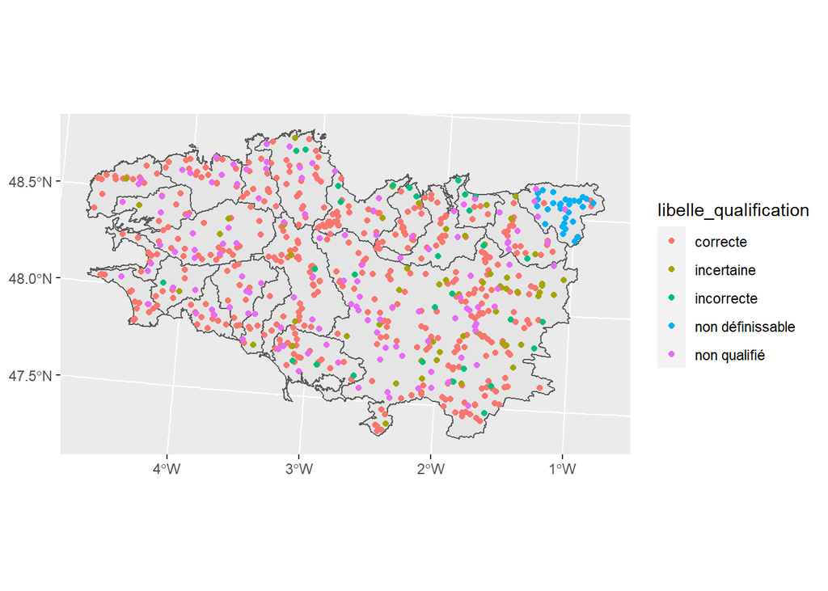

```r
resultats_sages %>%
  ggplot()+
  geom_sf(data=sages)+
geom_sf(aes(color=libelle_qualification))
```

## Exemple de résulat : Carte de l’indice Diatomées (IBD)

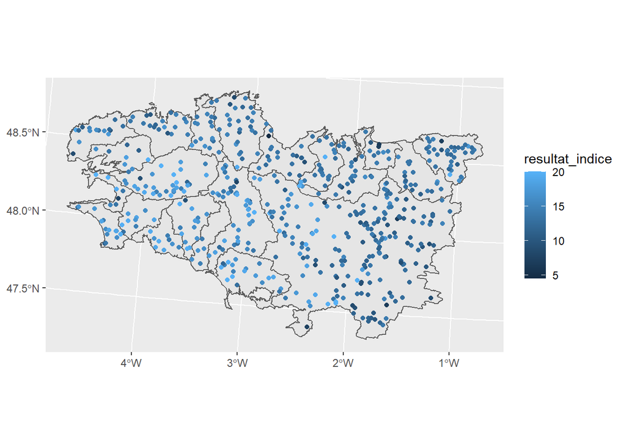

```r
resultats_sages %>%
  filter(code_indice == '5856')%>% #5856 IBD Indice Diatomées
  ggplot()+
  geom_sf(data=sages)+
geom_sf(aes(color=resultat_indice))
```

# Jointure avec les tables référentiels

## Sites inconnus

Les sites importés sont comparés à la table des sites bancarisés précédemment, par code SANDRE.

Liste des sites inconnus :

```r
sites_inconnus <- sites_sages %>%
  # tables des sites
  left_join(tbl(con_postgresql_dev, dbplyr::in_schema("eau_structure","site")), by=c("code_station_hydrobio" = "code"), copy=TRUE, suffix = c("", ".site"))%>%
  filter(is.na(site_id))

sites_inconnus %>%
  distinct(code_station_hydrobio, libelle_station_hydrobio)
```

```
## [1] code_station_hydrobio    libelle_station_hydrobio
## <0 rows> (or 0-length row.names)
```

Carte des sites inconnus :

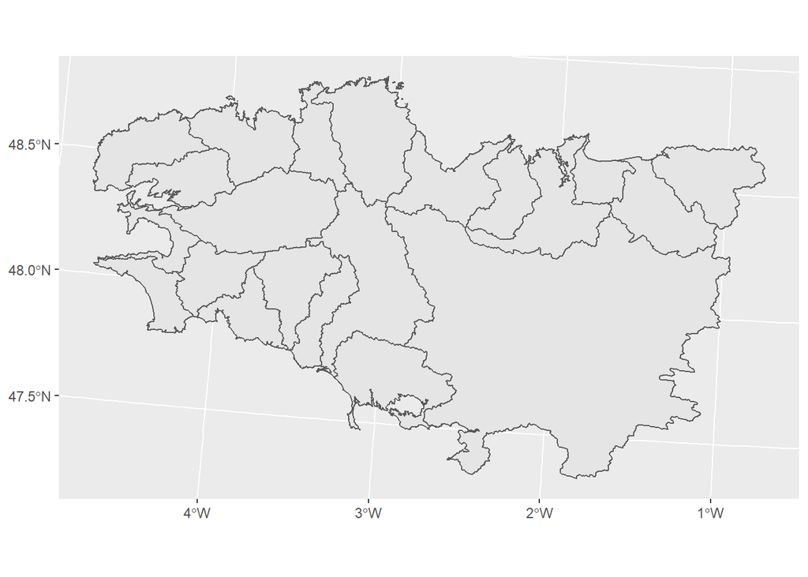

```r
sites_inconnus %>%
  ggplot()+
  geom_sf(data=sages)+
geom_sf(aes(color=libelle_departement))
```

### Mise en forme des nouveaux sites en fonction du schema de la table des sites bancarisés

```r
insert_sites <- sites_inconnus %>%
  mutate(coord_x = st_coordinates(st_transform(geometry, 2154))[,1],
         coord_y = st_coordinates(st_transform(geometry, 2154))[,2],
         longitude_wgs84 = st_coordinates(st_transform(geometry, 4326))[,1],
         latitude_wgs84 = st_coordinates(st_transform(geometry, 4326))[,2],
         typesite_id = '1',
         projection_id = '2154',
         source = 'OFB/NAIADES',
         maj = format(Sys.Date(),"%Y-%m-%d")
         )%>%
  as_tibble() %>%
select(code = code_station_hydrobio,
libelle = libelle_station_hydrobio,
typesite_id,
coord_x,
coord_y,
projection_id,
longitude_wgs84,
latitude_wgs84,
source,
maj)

insert_sites
```

```
## # A tibble: 0 x 10
## # ... with 10 variables: code <chr>, libelle <chr>, typesite_id <chr>,
## #   coord_x <lgl>, coord_y <lgl>, projection_id <chr>, longitude_wgs84 <lgl>,
## #   latitude_wgs84 <lgl>, source <chr>, maj <chr>
```

### Insertion des nouveaux sites

## Table de correspondance site / territoires (EGA - Entités Geographiques et Administratives)

La table de correspondance est issue de la jointure spatiale entre la table des sites et les différentes échelles de territoires bretons : Région, Départements, EPCI, SAGE, Contrats de territoires

```r
correspondance_site_ega <- tbl(con_postgresql_dev, dbplyr::in_schema("eau_referentiel","geo_correspondance_site_ega"))%>%
  mutate(typesite = 'SITE')

correspondance_site_ega
```

```
## # Source:   lazy query [?? x 9]
## # Database: postgres [postgres@localhost:/eau]
##    site_id site_geom      cdsite  lbsite  ega_id typeega  lbega   cdega typesite
##      <int> <chr>          <chr>   <chr>    <int> <chr>    <chr>   <chr> <chr>
##  1       1 0101000020E61~ ""      Pas de~      1 REGION   BRETAG~ 53    SITE
##  2       1 0101000020E61~ ""      Pas de~      3 DEPARTE~ FINIST~ 29    SITE
##  3       1 0101000020E61~ ""      Pas de~     17 SAGE     BAS LE~ SAGE~ SITE
##  4       1 0101000020E61~ ""      Pas de~     32 CONTRAT~ ABER I~ 1032  SITE
##  5       1 0101000020E61~ ""      Pas de~    199 EPCI     CC du ~ 2429~ SITE
##  6       2 0101000020E61~ "01Eco~ La Dou~      1 REGION   BRETAG~ 53    SITE
##  7       2 0101000020E61~ "01Eco~ La Dou~      3 DEPARTE~ FINIST~ 29    SITE
##  8       2 0101000020E61~ "01Eco~ La Dou~     19 SAGE     AULNE   SAGE~ SITE
##  9       2 0101000020E61~ "01Eco~ La Dou~    215 EPCI     CC Mon~ 2000~ SITE
## 10       3 0101000020E61~ "02Eco~ L'Aulne      1 REGION   BRETAG~ 53    SITE
## # ... with more rows
```

## Liste des paramètres bancarisés

La liste des paramètres est issue du dictionnaire national des données sur l’eau (SANDRE).

```r
liste_parametres <- as.list(strsplit(params$codes_parametres, ",")[[1]])

parametres <- tbl(con_postgresql_dev, dbplyr::in_schema("eau_structure","parametre"))%>%
  collect() %>%
  filter(code %in% liste_parametres)

parametres
```

```
## # A tibble: 10 x 9
##    parametre_id code  libelle      libelle_court definition    source maj
##           <int> <chr> <chr>        <chr>         <chr>         <chr>  <date>
##  1          304 1022  "Indice pol~ IPS           "Indice diat~ SANDRE 2021-09-22
##  2         1153 2928  "Indice Bio~ IBMR          "Cet indice ~ SANDRE 2021-09-22
##  3         1550 6951  "Indice mac~ MGCE 12Pre    "Indice calc~ SANDRE 2021-09-22
##  4         1554 6955  "Variété ta~ MGCE Va 12    "Variété tax~ SANDRE 2021-09-22
##  5         1614 6959  "Groupe Fau~ MGCE G 12     "Niveau du g~ SANDRE 2021-09-22
##  6         1678 7036  "Indice Poi~ IPR           "Indice étab~ SANDRE 2021-09-22
##  7         1701 5856  "Indice Bio~ IBD           "Indice Biol~ SANDRE 2021-09-22
##  8         1724 5910  "Indice dit~ MPCE A+B      "Indice calc~ SANDRE 2021-09-22
##  9         1749 2527  "Indice Bio~ IBGA          "Nombre de 0~ SANDRE 2021-09-22
## 10         1757 1000  "Indice Bio~ IBGN          "Nombre de 0~ SANDRE 2021-09-22
## # ... with 2 more variables: categorie <chr>, code_cas <chr>
```

## Seuils de qualité DCE

La liste des seuils de qualité est produite à partir de l’[Arrêté du 27 juillet 2018](https://www.legifrance.gouv.fr/jorf/article_jo/JORFARTI000037347782) disponible sur Legifrance[^footnote]

[^footnote] [Arrêté du 27 juillet 2018 modifiant l’arrêté du 25 janvier 2010 relatif aux méthodes et critères d’évaluation de l’état écologique, de l’état chimique et du potentiel écologique des eaux de surface pris en application des articles R. 212-10, R. 212-11 et R. 212-18 du code de l’environnement - Légifrance (legifrance.gouv.fr)](https://www.legifrance.gouv.fr/jorf/article_jo/JORFARTI000037347782)

```r
classes_qualite <- tbl(con_postgresql_dev, dbplyr::in_schema("eau_structure","join_parametre_classe"))%>%
  left_join(tbl(con_postgresql_dev, dbplyr::in_schema("eau_structure","classe")), by="classe_id")%>%
  left_join( select(tbl(con_postgresql_dev, dbplyr::in_schema("eau_structure","parametre")),parametre_id,libelle, code), by="parametre_id")%>%
  collect()%>%
  filter(parametre_id %in% parametres$parametre_id,
         valide == 1)

classes_qualite %>%
  select(libelle.y, code.y, parametre_id, libelle_court, code.x, borne_inf_inclue, borne_sup_exclue, source)
```

```
## # A tibble: 50 x 8
##    libelle.y           code.y parametre_id libelle_court code.x borne_inf_inclue
##    <chr>               <chr>         <int> <chr>         <chr>             <dbl>
##  1 Indice polluosensi~ 1022            304 Mauvais       5                  0
##  2 Indice polluosensi~ 1022            304 Médiocre      4                  5
##  3 Indice polluosensi~ 1022            304 Moyen         3                  9
##  4 Indice polluosensi~ 1022            304 Bon           2                 13
##  5 Indice polluosensi~ 1022            304 Très bon      1                 17
##  6 Indice Biologique ~ 2928           1153 Mauvais       5                  0
##  7 Indice Biologique ~ 2928           1153 Médiocre      4                  6.68
##  8 Indice Biologique ~ 2928           1153 Moyen         3                  8.38
##  9 Indice Biologique ~ 2928           1153 Bon           2                 10.1
## 10 Indice Biologique ~ 2928           1153 Très bon      1                 12.0
## # ... with 40 more rows, and 2 more variables: borne_sup_exclue <dbl>,
## #   source <chr>
```

## Table complète

Table des résultats avec les attributs des référentiels

```r
table_indices <- resultats_sages %>%
  mutate(CoordX_WGS84 = st_coordinates(st_transform(geometry, 4326))[,1],
         CoordY_WGS84 = st_coordinates(st_transform(geometry, 4326))[,2],
         date_prelevement = as.Date(date_prelevement)
         )%>%
  as_tibble()%>%
  # tables des paramètres
  left_join(parametres, by=c("code_indice"="code"), suffix = c("", ".parametre"))%>%
  # Unité inconnue --> code sandre 0
  # n (nombre) --> code sandre 214
  # ‰ vs SMOW --> code sandre 32
  mutate(unite_code = case_when(unite_indice == "Unité inconnue" ~ '0',
                                  unite_indice == "n" ~ '214',
                                  unite_indice == "‰ vs SMOW" ~ '32',
                                  TRUE ~ unite_indice),
         resultat_indice = ifelse(resultat_indice == 999, NA, resultat_indice)) %>%
  # tables des unités
  left_join(tbl(con_postgresql_dev, dbplyr::in_schema("eau_referentiel","unite")), by=c("unite_code" = "code"), copy=TRUE, suffix = c("", ".unite"))%>%
  # tables des sites
  left_join(tbl(con_postgresql_dev, dbplyr::in_schema("eau_structure","site")), by=c("code_station_hydrobio" = "code"), copy=TRUE, suffix = c("", ".site"))

table_indices
```

```
## # A tibble: 16,006 x 79
##    code_indice libelle_indice code_station_hy~ libelle_station~ uri_station_hyd~
##    <chr>       <chr>          <chr>            <chr>            <lgl>
##  1 1000        Indice Biolog~ 04187500         AER à CROISTY (~ NA
##  2 1000        Indice Biolog~ 04187500         AER à CROISTY (~ NA
##  3 1000        Indice Biolog~ 04187525         ELLE à FAOUET (~ NA
##  4 1000        Indice Biolog~ 04187525         ELLE à FAOUET (~ NA
##  5 1000        Indice Biolog~ 04187600         RAU DU MOULIN D~ NA
##  6 1000        Indice Biolog~ 04187600         RAU DU MOULIN D~ NA
##  7 1000        Indice Biolog~ 04187701         STER LAER ou IN~ NA
##  8 1000        Indice Biolog~ 04187710         STER LAER ou IN~ NA
##  9 1000        Indice Biolog~ 04187710         STER LAER ou IN~ NA
## 10 1000        Indice Biolog~ 04190550         SCORFF à PONT-S~ NA
## # ... with 15,996 more rows, and 74 more variables: date_prelevement <date>,
## #   resultat_indice <dbl>, unite_indice <chr>, code_projection <chr>,
## #   code_cours_eau <chr>, libelle_cours_eau <lgl>, uri_cours_eau <lgl>,
## #   code_masse_eau <chr>, libelle_masse_eau <chr>, uri_masse_eau <lgl>,
## #   code_sous_bassin <chr>, libelle_sous_bassin <chr>, code_bassin <chr>,
## #   libelle_bassin <chr>, code_commune <chr>, libelle_commune <chr>,
## #   code_departement <chr>, libelle_departement <chr>, code_region <chr>, ...
```

### Synthèse des données manquantes

```r
# Synthèse des données manquantes
table_indices %>%
  summarise(
    nb_lignes = n(),
    lignes_sans_parametre = sum(is.na(parametre_id)),
    lignes_sans_unite = sum(is.na(unite_id)),
    lignes_sans_sites = sum(is.na(site_id))
  )
```

```
## # A tibble: 1 x 4
##   nb_lignes lignes_sans_parametre lignes_sans_unite lignes_sans_sites
##       <int>                 <int>             <int>             <int>
## 1     16006                     0                 0                 0
```

```r
# Unités inconnues de la table de référence
table_indices %>% filter(is.na(unite_id)) %>% distinct(unite_indice)
```

```
## # A tibble: 0 x 1
## # ... with 1 variable: unite_indice <chr>
```

```r
# Stations inconnues de la table des sites
table_indices %>% filter(is.na(site_id)) %>% distinct(libelle_station_hydrobio)
```

```
## # A tibble: 0 x 1
## # ... with 1 variable: libelle_station_hydrobio <chr>
```

```r
# Liste des codes indices
table_indices %>% distinct(code_indice)
```

```
## # A tibble: 10 x 1
##    code_indice
##    <chr>
##  1 1000
##  2 1022
##  3 2527
##  4 2928
##  5 5856
##  6 5910
##  7 6951
##  8 6955
##  9 6959
## 10 7036
```

## Classes des indices

Attribution des classes de qualité aux résultats par paramètre (indice biologique)

```r
table_indices_classes <- table_indices %>%
  left_join(classes_qualite, by = c("parametre_id"), copy = TRUE, suffix=c("",".classe")) %>%
  filter(resultat_indice < borne_sup_exclue & resultat_indice >= borne_inf_inclue)

table_indices_classes
```

```
## # A tibble: 15,998 x 96
##    code_indice libelle_indice code_station_hy~ libelle_station~ uri_station_hyd~
##    <chr>       <chr>          <chr>            <chr>            <lgl>
##  1 1000        Indice Biolog~ 04187500         AER à CROISTY (~ NA
##  2 1000        Indice Biolog~ 04187500         AER à CROISTY (~ NA
##  3 1000        Indice Biolog~ 04187525         ELLE à FAOUET (~ NA
##  4 1000        Indice Biolog~ 04187525         ELLE à FAOUET (~ NA
##  5 1000        Indice Biolog~ 04187600         RAU DU MOULIN D~ NA
##  6 1000        Indice Biolog~ 04187600         RAU DU MOULIN D~ NA
##  7 1000        Indice Biolog~ 04187701         STER LAER ou IN~ NA
##  8 1000        Indice Biolog~ 04187710         STER LAER ou IN~ NA
##  9 1000        Indice Biolog~ 04187710         STER LAER ou IN~ NA
## 10 1000        Indice Biolog~ 04190550         SCORFF à PONT-S~ NA
## # ... with 15,988 more rows, and 91 more variables: date_prelevement <date>,
## #   resultat_indice <dbl>, unite_indice <chr>, code_projection <chr>,
## #   code_cours_eau <chr>, libelle_cours_eau <lgl>, uri_cours_eau <lgl>,
## #   code_masse_eau <chr>, libelle_masse_eau <chr>, uri_masse_eau <lgl>,
## #   code_sous_bassin <chr>, libelle_sous_bassin <chr>, code_bassin <chr>,
## #   libelle_bassin <chr>, code_commune <chr>, libelle_commune <chr>,
## #   code_departement <chr>, libelle_departement <chr>, code_region <chr>, ...
```

# Exploration des données

## Données disponibles par an et par indice

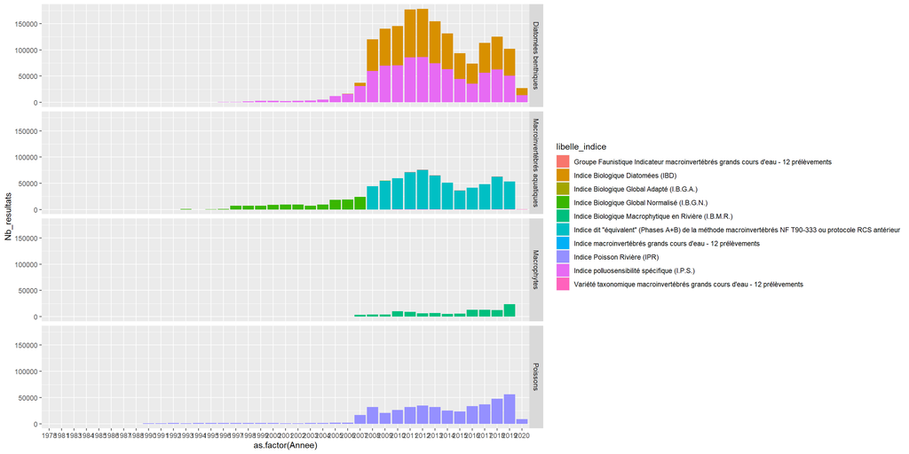

```r
table_indices_classes %>%
  group_by(year(date_prelevement), libelle_support, libelle_indice) %>%
  summarise(Nb_resultats = n(),
            Annee = year(date_prelevement)) %>%
  ggplot(aes(x = as.factor(Annee), y=Nb_resultats, fill=libelle_indice))+
           geom_bar(stat="identity")+
  facet_grid(libelle_support~.)
```

## Distribution des résultats par indice et par classe de qualité

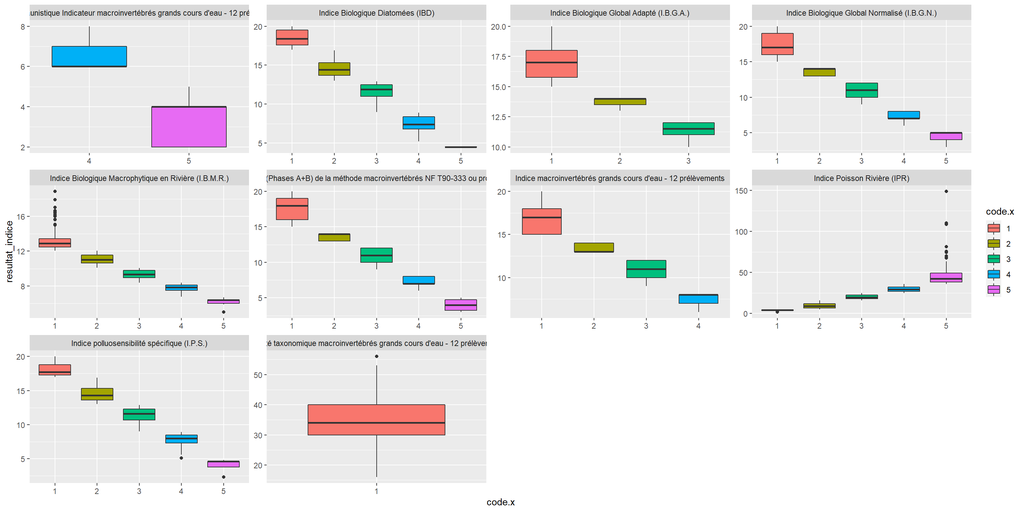

```r
table_indices_classes %>%
  arrange(code.x)%>%
  ggplot(aes(x = code.x, y=resultat_indice, fill = code.x))+
           geom_boxplot()+
  facet_wrap(~libelle_indice, scales = "free")
```

```r
table_indices_classes
```

```
## # A tibble: 15,998 x 96
##    code_indice libelle_indice code_station_hy~ libelle_station~ uri_station_hyd~
##    <chr>       <chr>          <chr>            <chr>            <lgl>
##  1 1000        Indice Biolog~ 04187500         AER à CROISTY (~ NA
##  2 1000        Indice Biolog~ 04187500         AER à CROISTY (~ NA
##  3 1000        Indice Biolog~ 04187525         ELLE à FAOUET (~ NA
##  4 1000        Indice Biolog~ 04187525         ELLE à FAOUET (~ NA
##  5 1000        Indice Biolog~ 04187600         RAU DU MOULIN D~ NA
##  6 1000        Indice Biolog~ 04187600         RAU DU MOULIN D~ NA
##  7 1000        Indice Biolog~ 04187701         STER LAER ou IN~ NA
##  8 1000        Indice Biolog~ 04187710         STER LAER ou IN~ NA
##  9 1000        Indice Biolog~ 04187710         STER LAER ou IN~ NA
## 10 1000        Indice Biolog~ 04190550         SCORFF à PONT-S~ NA
## # ... with 15,988 more rows, and 91 more variables: date_prelevement <date>,
## #   resultat_indice <dbl>, unite_indice <chr>, code_projection <chr>,
## #   code_cours_eau <chr>, libelle_cours_eau <lgl>, uri_cours_eau <lgl>,
## #   code_masse_eau <chr>, libelle_masse_eau <chr>, uri_masse_eau <lgl>,
## #   code_sous_bassin <chr>, libelle_sous_bassin <chr>, code_bassin <chr>,
## #   libelle_bassin <chr>, code_commune <chr>, libelle_commune <chr>,
## #   code_departement <chr>, libelle_departement <chr>, code_region <chr>, ...
```

# Transformation des données

## Données annuelles

Données aggrégées par année d’analyse :

- Indices moyens
- Classes maximales

```r
table_indices_classes_annee <- table_indices_classes %>%
  mutate(Annee = year(as.Date(date_prelevement))) %>%
  group_by(code_station_hydrobio,
           longitude_wgs84,
           latitude_wgs84,
           libelle_support,
           code_indice,
           parametre_id,
           libelle,
           symbole,
           Annee) %>%
  summarise(classe = as.integer(max(code.x)),
            resultat_indice = mean(resultat_indice),
            resultat_qualification = as.integer(max(code_qualification)))
table_indices_classes_annee
```

```
## # A tibble: 15,099 x 12
## # Groups:   code_station_hydrobio, longitude_wgs84, latitude_wgs84,
## #   libelle_support, code_indice, parametre_id, libelle, symbole [3,195]
##    code_station_hyd~ longitude_wgs84 latitude_wgs84 libelle_support  code_indice
##    <chr>                       <dbl>          <dbl> <chr>            <chr>
##  1 03271215                   -0.856           48.6 Diatomées benth~ 1022
##  2 03271215                   -0.856           48.6 Diatomées benth~ 5856
##  3 03271260                   -0.873           48.6 Diatomées benth~ 1022
##  4 03271260                   -0.873           48.6 Diatomées benth~ 5856
##  5 03271260                   -0.873           48.6 Macroinvertébré~ 5910
##  6 03271280                   -0.876           48.6 Diatomées benth~ 1022
##  7 03271280                   -0.876           48.6 Diatomées benth~ 5856
##  8 03271280                   -0.876           48.6 Macroinvertébré~ 5910
##  9 03271360                   -0.939           48.6 Diatomées benth~ 1022
## 10 03271360                   -0.939           48.6 Diatomées benth~ 5856
## # ... with 15,089 more rows, and 7 more variables: parametre_id <int>,
## #   libelle <chr>, symbole <chr>, Annee <dbl>, classe <int>,
## #   resultat_indice <dbl>, resultat_qualification <int>
```

## Classe de qualité biologique globale

Calcul d’une classe de *qualité biologique globale* (maximum des classes des indices annuels)

```r
table_indices_classe_globale_annee <- table_indices_classes_annee %>%
  group_by(code_station_hydrobio, longitude_wgs84, latitude_wgs84, Annee)%>%
  summarise(Resultat = max(classe))%>%
  mutate(Serie = 'Classe - Qualité biologique Globale',
         libelle_support = 'Qualité biologique Globale',
         symbole = 'X')
table_indices_classe_globale_annee
```

```
## # A tibble: 5,535 x 8
## # Groups:   code_station_hydrobio, longitude_wgs84, latitude_wgs84 [700]
##    code_station_hydrobio longitude_wgs84 latitude_wgs84 Annee Resultat Serie
##    <chr>                           <dbl>          <dbl> <dbl>    <int> <chr>
##  1 03271215                       -0.856           48.6  2017        3 Classe -~
##  2 03271260                       -0.873           48.6  2019        3 Classe -~
##  3 03271280                       -0.876           48.6  2019        3 Classe -~
##  4 03271360                       -0.939           48.6  2014        2 Classe -~
##  5 03271360                       -0.939           48.6  2017        3 Classe -~
##  6 03271385                       -0.913           48.6  2017        2 Classe -~
##  7 03271415                       -0.941           48.6  2003        2 Classe -~
##  8 03271415                       -0.941           48.6  2004        2 Classe -~
##  9 03271415                       -0.941           48.6  2005        2 Classe -~
## 10 03271415                       -0.941           48.6  2006        2 Classe -~
## # ... with 5,525 more rows, and 2 more variables: libelle_support <chr>,
## #   symbole <chr>
```

# Import des données en base

## Données au format de la table eau_structure.analyse_bio_esu - serveur PostgreSQL DEV

### Mise en forme de la table

```r
analyse_bio_esu <- table_indices %>%
  filter(!is.na(resultat_indice))%>%
  left_join(select(tbl(con_postgresql_dev, dbplyr::in_schema("eau_structure","date")), date_id, date_du_jour), by=c("date_prelevement" = "date_du_jour"), copy=TRUE)%>%
  left_join(select(tbl(con_postgresql_dev, dbplyr::in_schema("eau_structure","support")), support_id, code), by=c("code_support" = "code"), copy=TRUE)%>%
  left_join(select(tbl(con_postgresql_dev, dbplyr::in_schema("eau_structure","remarque")), remarque_id, code), by=c("code_qualification" = "code"), copy=TRUE)%>%
  mutate(prelevement_code = paste0(code_station_hydrobio,date_id),
         rdd_id = 0,
         milieu_id = 3,
         fraction_id = 22,
         limite_quantification = 0,
         source = 'OFB/NAIADES',
         maj = format(Sys.Date(),"%Y-%m-%d"))%>%
  select(site_id,
         date_id,
         rdd_id,
         prelevement_code,
         milieu_id,
         support_id,
         fraction_id,
         parametre_id,
         resultat = resultat_indice,
         remarque_id,
         limite_quantification,
         source,
         maj)

analyse_bio_esu
```

```
## # A tibble: 15,998 x 13
##    site_id  date_id rdd_id prelevement_code milieu_id support_id fraction_id
##      <int>    <int>  <dbl> <chr>                <dbl>      <int>       <dbl>
##  1    1774 20070710      0 0418750020070710         3         22          22
##  2    1774 20070925      0 0418750020070925         3         22          22
##  3    1775 20070806      0 0418752520070806         3         22          22
##  4    1775 20070924      0 0418752520070924         3         22          22
##  5    1776 20070710      0 0418760020070710         3         22          22
##  6    1776 20070924      0 0418760020070924         3         22          22
##  7    1777 20041002      0 0418770120041002         3         22          22
##  8    1778 20070718      0 0418771020070718         3         22          22
##  9    1778 20070925      0 0418771020070925         3         22          22
## 10    1849 19970924      0 0419055019970924         3         22          22
## # ... with 15,988 more rows, and 6 more variables: parametre_id <int>,
## #   resultat <dbl>, remarque_id <int>, limite_quantification <dbl>,
## #   source <chr>, maj <chr>
```

### Sélection des nouvelles lignes à insérer

```r
# TODO comparaison avec la base
insert_analyse_bio_esu <- analyse_bio_esu
```

### Insertion des nouvelles lignes

## Données au format de la table eau_tbi.oeb_eau_qualite_biologique_ce - serveur MariaDB OEB

```r
table_series_indices <- table_indices_classes_annee %>%
  mutate(indice = paste(libelle, code_indice, sep=' - '))%>%
  pivot_longer(cols= c("classe","resultat_indice","resultat_qualification"))%>%
  mutate(Serie = case_when(name == 'classe' ~ paste('Classe',libelle_support,sep = ' - '),
                           name == 'resultat_indice' ~ paste('Indice',indice,sep = ' - '),
                           name == 'resultat_qualification' ~ paste('Qualification',indice,sep = ' - ')
                           )
         )%>%
  group_by(code_station_hydrobio,
           longitude_wgs84,
           latitude_wgs84,
           libelle_support,
           Serie,
           symbole,
           Annee)%>%
  summarise(Resultat = max(value))%>%
  ungroup()%>%
  union(table_indices_classe_globale_annee)
table_series_indices
```

```
## # A tibble: 47,345 x 8
## # Groups:   code_station_hydrobio, longitude_wgs84, latitude_wgs84 [700]
##    code_station_hy~ longitude_wgs84 latitude_wgs84 libelle_support Serie symbole
##    <chr>                      <dbl>          <dbl> <chr>           <chr> <chr>
##  1 03271215                  -0.856           48.6 Diatomées bent~ Clas~ -
##  2 03271215                  -0.856           48.6 Diatomées bent~ Indi~ -
##  3 03271215                  -0.856           48.6 Diatomées bent~ Indi~ -
##  4 03271215                  -0.856           48.6 Diatomées bent~ Qual~ -
##  5 03271215                  -0.856           48.6 Diatomées bent~ Qual~ -
##  6 03271260                  -0.873           48.6 Diatomées bent~ Clas~ -
##  7 03271260                  -0.873           48.6 Diatomées bent~ Indi~ -
##  8 03271260                  -0.873           48.6 Diatomées bent~ Indi~ -
##  9 03271260                  -0.873           48.6 Diatomées bent~ Qual~ -
## 10 03271260                  -0.873           48.6 Diatomées bent~ Qual~ -
## # ... with 47,335 more rows, and 2 more variables: Annee <dbl>, Resultat <dbl>
```

### Déclinaison par combinaison SITE / EGA

La table de valorisation décline les résultats pour chaque échelle de territoire

```r
table_series_indices_ega <- table_series_indices%>%
  # table des correspondances sites / UGA
  left_join(correspondance_site_ega, by=c("code_station_hydrobio" = "cdsite"), copy = TRUE)%>%
  left_join(sites_rcs, by="code_station_hydrobio")

table_series_indices_ega
```

```
## # A tibble: 224,033 x 18
## # Groups:   code_station_hydrobio, longitude_wgs84, latitude_wgs84 [700]
##    code_station_hy~ longitude_wgs84 latitude_wgs84 libelle_support Serie symbole
##    <chr>                      <dbl>          <dbl> <chr>           <chr> <chr>
##  1 03271215                  -0.856           48.6 Diatomées bent~ Clas~ -
##  2 03271215                  -0.856           48.6 Diatomées bent~ Clas~ -
##  3 03271215                  -0.856           48.6 Diatomées bent~ Indi~ -
##  4 03271215                  -0.856           48.6 Diatomées bent~ Indi~ -
##  5 03271215                  -0.856           48.6 Diatomées bent~ Indi~ -
##  6 03271215                  -0.856           48.6 Diatomées bent~ Indi~ -
##  7 03271215                  -0.856           48.6 Diatomées bent~ Qual~ -
##  8 03271215                  -0.856           48.6 Diatomées bent~ Qual~ -
##  9 03271215                  -0.856           48.6 Diatomées bent~ Qual~ -
## 10 03271215                  -0.856           48.6 Diatomées bent~ Qual~ -
## # ... with 224,023 more rows, and 12 more variables: Annee <dbl>,
## #   Resultat <dbl>, site_id <int>, site_geom <chr>, lbsite <chr>, ega_id <int>,
## #   typeega <chr>, lbega <chr>, cdega <chr>, typesite <chr>, inclus_rcs <lgl>,
## #   geometry <POINT [m]>
```

### Mise en forme de la table

```r
oeb_eau_qualite_biologique_ce <- table_series_indices_ega %>%
  mutate(Periode = as.character(Annee),
         Source = 'OFB/NAIADES',
         Mise_a_jour = format(Sys.Date(),"%Y-%m-%d")
         )%>%
  select(Type_entitite_geographique = typesite,
         Code_entitite_geographique = code_station_hydrobio,
         Libelle_entitite_geographique = lbsite,
         CoordX_WGS84 = longitude_wgs84,
         CoordY_WGS84 = latitude_wgs84,
         Reseau_RCS = inclus_rcs,
         Type_entitite_geographique_associee = typeega,
         Code_entitite_geographique_associee = cdega,
         Libelle_entitite_geographique_associee = lbega,
         Periode,
         Serie,
         unite = symbole,
         Resultat,
         Source,
         Mise_a_jour
  )

oeb_eau_qualite_biologique_ce
```

```
## # A tibble: 224,033 x 15
## # Groups:   Code_entitite_geographique, CoordX_WGS84, CoordY_WGS84 [700]
##    Type_entitite_ge~ Code_entitite_g~ Libelle_entitit~ CoordX_WGS84 CoordY_WGS84
##    <chr>             <chr>            <chr>                   <dbl>        <dbl>
##  1 SITE              03271215         LE RUISSEAU DU ~       -0.856         48.6
##  2 SITE              03271215         LE RUISSEAU DU ~       -0.856         48.6
##  3 SITE              03271215         LE RUISSEAU DU ~       -0.856         48.6
##  4 SITE              03271215         LE RUISSEAU DU ~       -0.856         48.6
##  5 SITE              03271215         LE RUISSEAU DU ~       -0.856         48.6
##  6 SITE              03271215         LE RUISSEAU DU ~       -0.856         48.6
##  7 SITE              03271215         LE RUISSEAU DU ~       -0.856         48.6
##  8 SITE              03271215         LE RUISSEAU DU ~       -0.856         48.6
##  9 SITE              03271215         LE RUISSEAU DU ~       -0.856         48.6
## 10 SITE              03271215         LE RUISSEAU DU ~       -0.856         48.6
## # ... with 224,023 more rows, and 10 more variables: Reseau_RCS <lgl>,
## #   Type_entitite_geographique_associee <chr>,
## #   Code_entitite_geographique_associee <chr>,
## #   Libelle_entitite_geographique_associee <chr>, Periode <chr>, Serie <chr>,
## #   unite <chr>, Resultat <dbl>, Source <chr>, Mise_a_jour <chr>
```

### Sélection des lignes nouvelles à insérer

La table de résultats est comparée aux données déjà bancarisées par une jointure d’exclusion (anti_join). Les lignes restantes peuvent être insérées.

```r
insert_oeb_eau_qualite_biologique_ce <- oeb_eau_qualite_biologique_ce %>%
  ungroup() %>%
  # Retirer les lignes des résultats déjà existants dans la table
  anti_join(tbl(con_eau_tbi,"oeb_eau_qualite_biologique_ce", by=c("Type_entitite_geographique", "Code_entitite_geographique", "Type_entitite_geographique_associee", "Code_entitite_geographique_associee", "Periode", "Serie")), copy = TRUE)%>%
  # Retirer les stations hydro sans EGA identifiée
  filter(!is.na(Type_entitite_geographique))%>%
  # Retirer les lignes avec une valeur NA
  drop_na()
insert_oeb_eau_qualite_biologique_ce
```

```
## # A tibble: 224,033 x 15
##    Type_entitite_ge~ Code_entitite_g~ Libelle_entitit~ CoordX_WGS84 CoordY_WGS84
##    <chr>             <chr>            <chr>                   <dbl>        <dbl>
##  1 SITE              03271215         LE RUISSEAU DU ~       -0.856         48.6
##  2 SITE              03271215         LE RUISSEAU DU ~       -0.856         48.6
##  3 SITE              03271215         LE RUISSEAU DU ~       -0.856         48.6
##  4 SITE              03271215         LE RUISSEAU DU ~       -0.856         48.6
##  5 SITE              03271215         LE RUISSEAU DU ~       -0.856         48.6
##  6 SITE              03271215         LE RUISSEAU DU ~       -0.856         48.6
##  7 SITE              03271215         LE RUISSEAU DU ~       -0.856         48.6
##  8 SITE              03271215         LE RUISSEAU DU ~       -0.856         48.6
##  9 SITE              03271215         LE RUISSEAU DU ~       -0.856         48.6
## 10 SITE              03271215         LE RUISSEAU DU ~       -0.856         48.6
## # ... with 224,023 more rows, and 10 more variables: Reseau_RCS <lgl>,
## #   Type_entitite_geographique_associee <chr>,
## #   Code_entitite_geographique_associee <chr>,
## #   Libelle_entitite_geographique_associee <chr>, Periode <chr>, Serie <chr>,
## #   unite <chr>, Resultat <dbl>, Source <chr>, Mise_a_jour <chr>
```

### Insertion des nouvelles lignes

## Exports CSV pour la publication du jeu de données sur les portails opendata

### Export pour le GIDE

Fichier pour la publication du jeu de données sur le portail OEB

```r
# Depuis la base de données
#tbl(con_eau_tbi, "oeb_eau_qualite_biologique_ce_new")%>%
# ou depuis la table en mémoire
oeb_eau_qualite_biologique_ce %>%
write.table(file = paste0(params$path_dataviz,"\\GIDE\\","oeb_eau_qualite_biologique_ce.csv"), quote = TRUE, sep = ";",
            eol = "\n", na = "", dec = ",",
            fileEncoding = "UTF-8")
```

### Export pour GEOB

Fichier pour la publication du jeu de données sur Geobretagne

#### Mise en forme de la table pour l’ensemble des paramètres

```r
oeb_eau_qualite_geob <- table_series_indices  %>%
  ungroup()%>%
  left_join(select(sites_sages,code_station_hydrobio,libelle_station_hydrobio), by="code_station_hydrobio")  %>%
  mutate(Code_entitite_geographique = code_station_hydrobio,
         Libelle_entitite_geographique = libelle_station_hydrobio,
         CoordX_WGS84 = longitude_wgs84,
         CoordY_WGS84 = latitude_wgs84,
         Serie,
         unite = symbole,
         Type_entitite_geographique = 'SITE',
         Source = 'OFB/NAIADES',
         Mise_a_jour = format(Sys.Date(),"%Y-%m-%d")) %>%
  select(Type_entitite_geographique,
         Code_entitite_geographique,
         Libelle_entitite_geographique,
         CoordX_WGS84,
         CoordY_WGS84,
         Serie,
         unite,
         Source,
         Mise_a_jour,
         Annee,
         Resultat) %>%
  pivot_wider(values_from = Resultat, names_from = Annee, names_sort=TRUE)
```

#### Export pour le paramètre “Qualité globale”

```r
oeb_eau_qualite_geob  %>%
  filter(Serie == 'Classe - Qualité biologique Globale')  %>%
write.table(file = paste0(params$path_dataviz,"\\GEOB\\","oeb_eau_qualite_biologique_globale.csv"), quote = TRUE, sep = ";",
            eol = "\n", na = "", dec = ",",
            fileEncoding = "UTF-8")
```

#### Export pour le paramètre “Diatomées”

```r
oeb_eau_qualite_geob %>%
  filter(Serie == 'Classe - Diatomées benthiques') %>%
write.table(file = paste0(params$path_dataviz,"\\GEOB\\","oeb_eau_qualite_diatomees.csv"), quote = TRUE, sep = ";",
            eol = "\n", na = "", dec = ",",
            fileEncoding = "UTF-8")
```

#### Export pour le paramètre “Macroinvertébrés”

```r
oeb_eau_qualite_geob %>%
  filter(Serie == 'Classe - Macroinvertébrés aquatiques') %>%
write.table(file = paste0(params$path_dataviz,"\\GEOB\\","oeb_eau_qualite_macroinvertebres.csv"), quote = TRUE, sep = ";",
            eol = "\n", na = "", dec = ",",
            fileEncoding = "UTF-8")
```

#### Export pour le paramètre “Macrophytes”

```r
oeb_eau_qualite_geob %>%
  filter(Serie == 'Classe - Macrophytes') %>%
write.table(file = paste0(params$path_dataviz,"\\GEOB\\","oeb_eau_qualite_macrophytes.csv"), quote = TRUE, sep = ";",
            eol = "\n", na = "", dec = ",",
            fileEncoding = "UTF-8")
```